# Project A

Andrea Celleri

# Art Museums

## Overview

The overarching purpose of this dataset is to perform exploratory data analysis to increase the understanding of the relationship or patterns that exist between the most visited art museums in the world. The museums that were chosen were based on the Art News Paper’s published figures of the most visited art museums in 2016. Once the museums were established, the other variables were located by researching each institution’s website or other databases.

## Data dictionary

Here is a data dictionary for the museums dataset:

- **name**: a character variable giving the full proper name of the art museum
- **country**: a character variable giving the country of location of the restaurant as “Country”
- **city**: a character variable giving the city of location of the restaurant as “City”
- **visitors_2016**: numeric number of people that visited the an specific art museum during the year 2016. Use only whole numbers. If less than 1, round down to zero.
- **visitors_2015**: numeric number of people that visited the an specific art museum during the year 2016. Use only whole numbers. If less than 1, round down to zero. – **size**: a categorical variable describing the size of the art museum. Possible options are:
  - *“Small”*
  - *“Medium”*
  - *“Large”*
- **year_established**: numeric number describing the year the art gallery was established. Format as “YYYY” with the four digit year.
- **metro_access**: a categorical variable explaining the accessibility of the art museum via subway. Possible options are:
  - “Yes”
  - “No”
- **free**: a categorical variable distinguishing if the art museum is has no fee. If it is free, the art museum is owned by a government entity or accessible to the public with no charge. Possible options are:
  - “Yes”
  - “No” .

Which can be read in as follows:

```r
museums <- read_csv("https://raw.githubusercontent.com/URstats/stat209-s18-andreacelleri/master/project_a_data.csv")
museums
```

| name | country | city | visitors_2016 | visitors_2015 | size | year_established | metro_access | free |
| --- | --- | --- | --- | --- | --- | --- | --- | --- |
| Louvre | France | Paris | 7400000 | 8600000 | Large | 1793 | Yes | No |
| Metropolitan Museum of Art | USA | New York City | 7006859 | 6533106 | Large | 1870 | Yes | Yes |
| British Museum | United Kingdom | London | 6420395 | 6820686 | Large | 1753 | Yes | Yes |
| National Gallery | United Kingdom | London | 6262839 | 5908254 | Large | 1824 | Yes | Yes |
| Vatican Museums | Italy | Vatican City | 6066649 | 6002251 | Large | 1506 | Yes | No |
| Tate Modern | United Kingdom | London | 5839197 | 4712581 | Medium | 2000 | Yes | Yes |
| National Gallery of Art | USA | Washigton, D.C | 4261391 | 4104331 | Large | 1937 | Yes | Yes |
| State Hermitage Museum | Russia | Saint Petersburg | 4119103 | 3668031 | Large | 1764 | Yes | No |
| Reina Sofia | Spain | Madrid | 3646598 | 3249591 | Large | 1992 | Yes | No |
| Somerset House | United Kingdom | London | 3443220 | 3235104 | Large | 1776 | Yes | Yes |

[output cut: 70 more lines]

## Exploratory Analysis

The dataset facilitated the discovery of interesting relationships and patterns between the most visited art museums in the world. Some of these include…

First, the relationship between the number of art museums by country and city was analyzed. The first graph shows that the United States and the United Kingdom have the highest number of most visited art museums. To better understand where the museums were concentrated, the second graph shows the relationship between the number of museums and city. The graph revealed that even if the United States has the highest aggregated number of museums, they are dispersed in many cities around the country. Additionally, it is determined that Paris and London have the highest concentrations of museums followed by Washington D.C. Both graphs also provide additional information including the size of the museum by city and whether or not the admission is free.

[figure not shown]

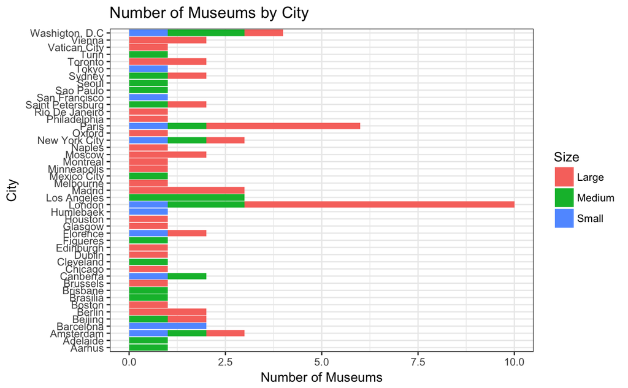

```r
ggplot(museums, aes(city, fill=size)) +
  theme_bw() +
  geom_bar()+
  labs(y= "Number of Museums", x="City", title="Number of Museums by City", fill= "Size") +
  coord_flip()
```

Regarding the third graph, it shows the relationship between the size of the museum and the number of visitors in 2016. The graph shows that most of the “large” museums have the highest number of visitors. The relationship proves that the capacity of the museum might have an impact on the number of visitors it receives.

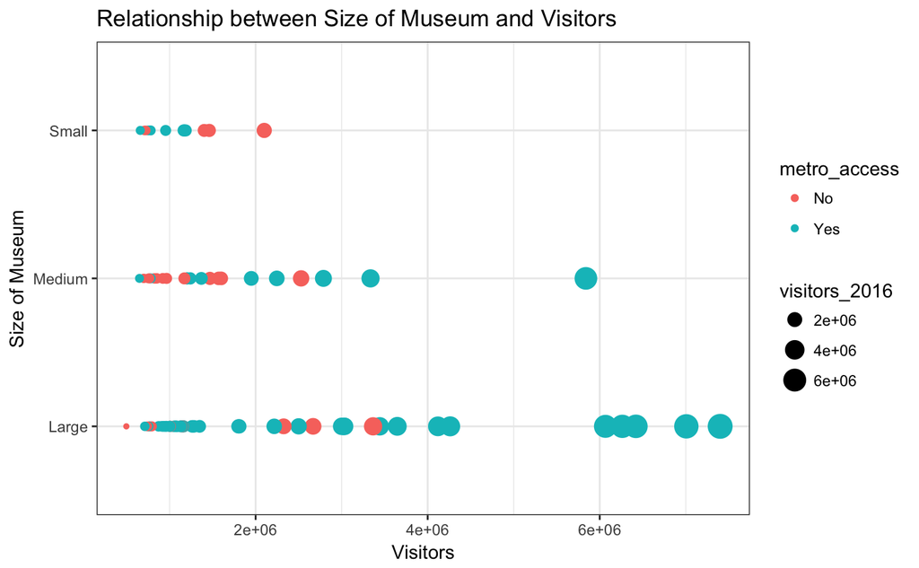

```r
ggplot(museums, aes(visitors_2016,size)) +
  theme_bw() +
  geom_point(aes(size=visitors_2016, color=metro_access)) +
  labs(x="Visitors", y="Size of Museum", title="Relationship between Size of Museum and Visitors")
```

The date the museum was established was also analyzed to see if it had a possible impact on the number of visitors. Graph 4, does not show any relationship between the two, however, it a larger dataset should be analyzed to better understand if there is a relationship between the two.

[figure not shown]

```r
ggplot(museums, aes(year_established,visitors_2016)) +
  theme_bw() +
  geom_point(aes(size=visitors_2016, color=metro_access)) +
  labs(x="Year", title="Relationship between Size of Museum and Visitors")
```

```r
NA
```

Last, the possible relationships between museums and time of establishment were analyzed. Graph 5 displays a histogram recording the number of museums established per year. There are three concentrated periods during which museum establishment was the most prominent. The first during 1750 to 1800, which could have been influenced by the Age of Reason which dominated Europe during that time. Countries where the museums were established during this time included the United Kingdom, Germany, France, and the Netherlands. The second period started around 1850 and ended around 1900. Many Countries in Europe established prominent museums during this time, with the highest number established in the UK and the United States. We also had the Impressionism, Post-Impressionist and Neo-impressionist movements during this time. The third largest period started around 1960 to 2000. This massive number must have started after the two world wars that occurred.

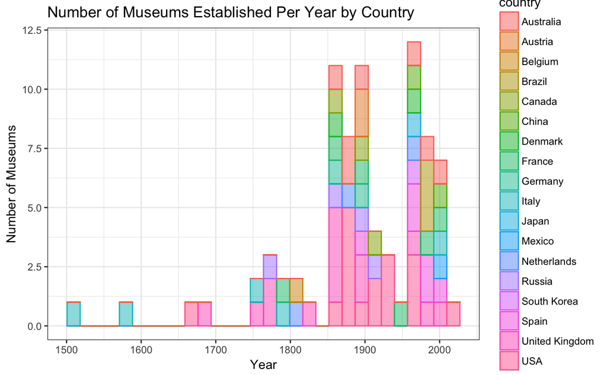

```r
ggplot(museums, aes(year_established, fill=country, color=country))+
  theme_bw() +
  geom_histogram(alpha=1/2)+
  labs(y="Number of Museums", title="Number of Museums Established Per Year by Country", x="Year")
```

```r
ggplot(museums, aes(visitors_2016,country)) +
  theme_bw() +
  geom_point (color="blue") +
  geom_point(aes(visitors_2015,country))
```

[output not shown]

## References

About. (n.d.). Retrieved from http://www.serpentinegalleries.org/about

Admission Fees - The Montreal Museum of Fine Arts. (n.d.). Retrieved from https://www.mbam.qc.ca/en/information/admission-fees/

Art Gallery of Ontario. (2018, February 3). Retrieved from https://en.wikipedia.org/wiki/Art_Gallery_of_Ontario

Art Gallery of South Australia. (2018, February 4). Retrieved from https://en.wikipedia.org/wiki/Art_Gallery_of_South_Australia

The Art Institute of Chicago. (n.d.). Retrieved from http://www.artic.edu/

The Broad. (n.d.). Retrieved from https://www.thebroad.org/visit/today

CaixaForum Barcelona. (2018, February 2). Retrieved from https://en.wikipedia.org/wiki/CaixaForum_Barcelona

Centro Cultural Banco do Brasil. (2017, June 11). Retrieved from https://en.wikipedia.org/wiki/Centro_Cultural_Banco_do_Brasil

Exhibitions — Minneapolis Institute of Art. (n.d.). Retrieved from https://new.artsmia.org/exhibitions/

FAMSF. (n.d.). Retrieved from https://www.famsf.org/

Galleria dell’Accademia. (2017, December 24). Retrieved from https://en.wikipedia.org/wiki/Galleria_dell%27Accademia

Gallery, S. (2017, September 27). Saatchi Gallery. Retrieved from http://www.saatchigallery.com/

Grand Palais. (2018, January 15). Retrieved from https://en.wikipedia.org/wiki/Grand_Palais

Grrr.nl. (n.d.). Stedelijk Museum Amsterdam. Retrieved from https://www.stedelijk.nl/en

Hermitage Museum. (2018, February 1). Retrieved from https://en.wikipedia.org/wiki/Hermitage_Museum

Home :: Art Gallery NSW. (n.d.). Retrieved from https://www.artgallery.nsw.gov.au/

Home | The Museum of Fine Arts, Houston. (n.d.). Retrieved from https://www.mfah.org/

Home. (n.d.). Retrieved from https://www.nationalgallery.ie/

J. Paul Getty Museum | The Getty. (n.d.). Retrieved from http://www.getty.edu/museum/

Kelvingrove Art Gallery and Museum. (2017, December 15). Retrieved from https://en.wikipedia.org/wiki/Kelvingrove_Art_Gallery_and_Museum

Kunsthistorisches Museum. (2018, January 18). Retrieved from https://en.wikipedia.org/wiki/Kunsthistorisches_Museum

Los Angeles County Museum of Art. (2018, January 6). Retrieved from https://en.wikipedia.org/wiki/Los_Angeles_County_Museum_of_Art

Louisiana. (n.d.). Retrieved from https://en.louisiana.dk/

Louvre Museum Official Website. (n.d.). Retrieved from https://www.louvre.fr/en

Met Audio Guide Online. (n.d.). Retrieved from https://www.metmuseum.org/

MoMA. (n.d.). Retrieved from https://www.moma.org/

Museo di Capodimonte. (2017, December 18). Retrieved from https://en.wikipedia.org/wiki/Museo_di_Capodimonte

Museo Nacional Centro de Arte Reina Sofía. (n.d.). Retrieved from http://www.museoreinasofia.es/en

Museo Nacional del Prado. (n.d.). Retrieved from https://www.museodelprado.es/en

Museo Nacional Thyssen-Bornemisza. (n.d.). Retrieved from https://www.museothyssen.org/en

Museo Soumaya. (n.d.). Retrieved from http://www.soumaya.com.mx/index.php/esp

Museum of Contemporary Art Australia. (2018, February 9). Retrieved from https://en.wikipedia.org/wiki/Museum_of_Contemporary_Art_Australia

Museum of Fine Arts, Boston. (n.d.). Retrieved from http://www.mfa.org/

Musée de l’Orangerie |. (n.d.). Retrieved from http://www.musee-orangerie.fr/en

Musée d’Orsay. (2018, February 9). Retrieved from https://en.wikipedia.org/wiki/Mus%C3%A9e_d%27Orsay

Musée du quai Branly - Jacques Chirac. (2018, January 9). Retrieved from https://en.wikipedia.org/wiki/Mus%C3%A9e_du_quai_Branly_-_Jacques_Chirac

Musée National d’Art Moderne. (2017, November 30). Retrieved from https://en.wikipedia.org/wiki/Mus%C3%A9e_National_d%27Art_Moderne

National Art Museum of China. (2017, July 19). Retrieved from https://en.wikipedia.org/wiki/National_Art_Museum_of_China

National Gallery of Art. (n.d.). Retrieved from https://www.nga.gov/

National Gallery of Art. (n.d.). Retrieved from https://www.nga.gov/

National gallery of australia. (n.d.). National Gallery of Australia - Home. Retrieved from https://nga.gov.au/

National Museum of Modern and Contemporary Art. (2017, October 17). Retrieved from https://en.wikipedia.org/wiki/National_Museum_of_Modern_and_Contemporary_Art

National Museum of Western Art. (2017, December 25). Retrieved from https://en.wikipedia.org/wiki/National_Museum_of_Western_Art

National Portrait Gallery, London. (2017, December 5). Retrieved from https://en.wikipedia.org/wiki/National_Portrait_Gallery,_London

Neues Museum. (2017, December 14). Retrieved from https://en.wikipedia.org/wiki/Neues_Museum

NGV. (n.d.). Retrieved from https://www.ngv.vic.gov.au/

Pergamon Museum. (2018, January 22). Retrieved from https://en.wikipedia.org/wiki/Pergamon_Museum

The Picasso Museum in Barcelona. (n.d.). Picasso Museum Barcelona | Official website. Retrieved from http://www.museupicasso.bcn.cat/en/

The Pushkin State Museum of Fine Arts - Official site. (n.d.). Retrieved from http://www.arts-museum.ru/?lang=en

Queensland Art Gallery. (2017, September 17). Retrieved from https://en.wikipedia.org/wiki/Queensland_Art_Gallery

Rijksmuseum - Google Search. (n.d.). Retrieved from https://www.google.com/search?q=Rijksmuseum&oq=Rijksmuseum&aqs=chrome..69i57j69i58j69i60l2.1992j0j4&sourceid=chrome&ie=UTF-8

Royal Academy of Arts. (n.d.). Retrieved from https://www.royalacademy.org.uk/

Royal Museums of Fine Arts of Belgium. (2017, December 3). Retrieved from https://en.wikipedia.org/wiki/Royal_Museums_of_Fine_Arts_of_Belgium

Russian Museum. (2018, February 4). Retrieved from https://en.wikipedia.org/wiki/Russian_Museum

Solomon R. Guggenheim Museum. (2018, January 26). Retrieved from https://en.wikipedia.org/wiki/Solomon_R._Guggenheim_Museum

Somerset House. (n.d.). Retrieved from https://www.somersethouse.org.uk/

Stephen Thompson | Satyr, British Museum | The Met. (n.d.). Retrieved from https://www.metmuseum.org/art/collection/search/285957

Tate. (n.d.). Tate. Retrieved from http://www.tate.org.uk/

Tretyakov Gallery. (2018, January 30). Retrieved from https://en.wikipedia.org/wiki/Tretyakov_Gallery

Uffizi Gallery Museum in Florence. Uffizi Tickets & Tours. (n.d.). Retrieved from http://www.uffizi.org/

Ullens Center for Contemporary Art. (2017, November 21). Retrieved from https://en.wikipedia.org/wiki/Ullens_Center_for_Contemporary_Art

Vatican Museums. (2018, February 7). Retrieved from https://en.wikipedia.org/wiki/Vatican_Museums

Victoria and Albert Museum. (2018, February 7). Retrieved from https://en.wikipedia.org/wiki/Victoria_and_Albert_Museum

Visit the museum about Vincent van Gogh in Amsterdam - The Netherlands - Van Gogh Museum. (n.d.). Retrieved from https://www.vangoghmuseum.nl/en

Visit the Renwick Gallery. (n.d.). Retrieved from https://americanart.si.edu/visit/renwick

Visitor Figures 2016. (n.d.). Retrieved from https://www.theartnewspaper.com/visitor-figures-2016

Welcome | Ashmolean Museum. (n.d.). Retrieved from https://www.ashmolean.org/